# Group trait slopes: HR against LR

Does the link between a feature (protein, gene-set score or module eigengene) and a muscle trait differ between HR and LR? The pooled, label-free version of the question is `03_Continuous/01_Trait_Associations`; this step asks only what the grouping adds. Two tests per feature, window and trait:

- Within each group: Spearman’s rho between the feature and the trait across that group’s 8 people, with its exact p. Descriptive only: a group split on growth has a narrowed range of growth inside it.
- Between groups: limma on feature ~ group × trait, one value per person. The interaction is HR’s slope minus LR’s slope, with its 95% interval. The composite hypertrophy score defined the groups, so it is left out of this test.

## Packages

```r
library(here)
library(limma)
library(dplyr)
library(tidyr)
library(purrr)
library(ggplot2)
source(here("00_Setup", "Shared_functions", "workbooks.R"))
source(here("00_Setup", "Shared_functions", "person_traits.R"))
inputs <- c(
  corrected = "01_Processing/03_Blood_Correction/c_data/blood_correction.rds",
  singscore = "01_Processing/05_Set_Scores/c_data/set_scores.rds",
  gene_sets = "01_Processing/04_Gene_Sets/c_data/gene_sets.rds",
  modules = "01_Processing/06_Module_Building/c_data/module_building.rds",
  phenotype = "00_Setup/Input/phenotype.csv"
)
paths <- vapply(inputs, here, character(1))
stopifnot(file.exists(paths))
```

## Input

Rank correlations take no covariate, so proteins come from the blood-corrected matrix.

```r
corrected <- readRDS(paths[["corrected"]])
catalog <- filter(readRDS(paths[["gene_sets"]])$set_catalog, qualifies)
modules <- readRDS(paths[["modules"]])
phenotype <- readr::read_csv(paths[["phenotype"]], show_col_types = FALSE)
meta <- as_tibble(corrected$targets)
loaded <- load_features(corrected, readRDS(paths[["singscore"]])$scores, catalog, modules, meta)
features <- loaded$features
label_of <- loaded$label_of
collection_of <- loaded$collection_of
group_of <- set_names(meta$group, meta$subject)
map(features, dim)
```

```
$proteins
[1] 2059   48

$sets
[1] 1422   48

$modules
[1] 10 48
```

## Trait change per group

Before any feature enters, how much did each group change? Each person’s T1 to T2 change in a trait is taken as the log ratio, log(post / pre), so a rise and a fall of the same size count the same. Within each group, a one-sample t-test gives the mean log ratio and its 95% interval; between groups, Welch’s t-test gives HR minus LR. Both are shown as % change (geometric mean). The composite hypertrophy score, (2 × %ΔmCSA + %ΔfCSA mixed) / 3, chose the groups, so HR beats LR on muscle area and mixed fibre area by construction; those two rows check the selection rather than test it.

```r
selection_traits <- c("mcsa", "fcsa_mixed")
log_ratios <- phenotype |>
  select(subject, group, matches("_(pre|post)_")) |>
  pivot_longer(
    matches("_(pre|post)_"),
    names_to = c("trait", "when"), names_pattern = "(.*)_(pre|post)_.*"
  ) |>
  filter(!startsWith(trait, "fibres_")) |>
  pivot_wider(names_from = when) |>
  filter(!is.na(pre), !is.na(post)) |>
  mutate(log_ratio = log(post / pre))
as_pct <- \(x) 100 * (exp(x) - 1)
t_row <- \(test) {
  broom::tidy(test) |>
    transmute(
      pct_change = as_pct(unname(estimate)), lower = as_pct(conf.low), upper = as_pct(conf.high),
      p = p.value
    )
}
within_change <- log_ratios |>
  reframe(n = n(), t_row(t.test(log_ratio)), .by = c(trait, group))
between_change <- log_ratios |>
  reframe(
    n = n(), t_row(t.test(log_ratio[group == "HR"], log_ratio[group == "LR"])),
    .by = trait
  ) |>
  mutate(group = "HR - LR")
trait_effects <- bind_rows(within_change, between_change) |>
  mutate(used_for_groups = trait %in% selection_traits, .after = trait) |>
  arrange(trait, match(group, c("HR", "LR", "HR - LR")))
trait_effects
```

```
# A tibble: 18 × 8
   trait         used_for_groups group       n pct_change  lower  upper        p
   <chr>         <lgl>           <chr>   <int>      <dbl>  <dbl>  <dbl>    <dbl>
 1 fcsa_mixed    TRUE            HR          8      15.6    4.96 27.4    9.36e-3
 2 fcsa_mixed    TRUE            LR          8     -15.2  -27.3  -1.12   3.88e-2
 3 fcsa_mixed    TRUE            HR - LR    16      36.4   15.3  61.3    1.71e-3
 4 fcsa_type1    FALSE           HR          8      15.9    5.79 26.9    6.48e-3
 5 fcsa_type1    FALSE           LR          8     -18.9  -33.2  -1.61   3.74e-2
 6 fcsa_type1    FALSE           HR - LR    16      42.9   16.8  74.8    2.76e-3
 7 fcsa_type2    FALSE           HR          8      17.3    8.53 26.8    1.86e-3
 8 fcsa_type2    FALSE           LR          8     -14.0  -25.6  -0.618  4.31e-2
 9 fcsa_type2    FALSE           HR - LR    16      36.4   17.0  59.1    1.01e-3
10 leg_ext_1rm   FALSE           HR          7      17.3    9.02 26.2    1.77e-3
11 leg_ext_1rm   FALSE           LR          8      13.0    4.20 22.5    9.17e-3
12 leg_ext_1rm   FALSE           HR - LR    15       3.81  -5.92 14.5    4.26e-1
13 leg_press_1rm FALSE           HR          8      33.6    8.81 63.9    1.25e-2
14 leg_press_1rm FALSE           LR          8      30.5    8.86 56.5    1.04e-2
15 leg_press_1rm FALSE           HR - LR    16       2.31 -20.2  31.2    8.46e-1
16 mcsa          TRUE            HR          8      11.5    8.43 14.6    3.36e-5
17 mcsa          TRUE            LR          8       3.40  -1.65  8.72   1.58e-1
18 mcsa          TRUE            HR - LR    16       7.79   2.19 13.7    1.02e-2
```

## Windows and traits

Each feature enters as one value per person in six windows (`window_values()` and `trait_windows()`, from `00_Setup/Shared_functions/person_traits.R`):

| window | feature value | traits |
| --- | --- | --- |
| `baseline_level` | T1 level | trait levels at T1 |
| `baseline` | T1 level | % change, composite score, volume load |
| `training` | change T1 → T2 | % change, composite score, volume load |
| `post_level` | T2 level | trait levels at T2 |
| `acute` | change T2 → T3 | % change, composite score, volume load |
| `post_bout_level` | T3 level | trait levels at T2 (T3 has no phenotype) |

```r
windows <- trait_windows(phenotype)
trait_of <- map(windows, \(d) setdiff(names(d), "subject"))
lengths(trait_of)
```

```
 baseline_level        baseline        training      post_level           acute
              6               8               8               6               8
post_bout_level
              6
```

## Tests

`within_group()` takes a feature-by-person matrix and one trait value per person and returns, per group and feature, the people used, rho and its exact p (`cor.test()`, which drops to a normal approximation where values tie). `slope_difference()` fits feature ~ group × trait with robust empirical Bayes and returns HR’s slope minus LR’s with its 95% interval, t and p. People without the trait are dropped from both. `fdr` is Benjamini-Hochberg within feature type, window, trait and test (and group, and collection for sets).

```r
within_group <- function(x, y) {
  map(set_names(c("HR", "LR")), \(g) {
    kept <- group_of[colnames(x)] == g & !is.na(y)
    tibble(
      feature = rownames(x), n_people = sum(kept),
      rho = cor(t(x[, kept]), y[kept], method = "spearman")[, 1],
      p = apply(x[, kept], 1, \(v) {
        suppressWarnings(cor.test(v, y[kept], method = "spearman"))$p.value
      })
    )
  }) |>
    list_rbind(names_to = "group")
}
slope_difference <- function(x, y) {
  kept <- !is.na(y)
  design <- model.matrix(~ group * trait, data.frame(
    group = factor(group_of[colnames(x)][kept], c("LR", "HR")), trait = y[kept]
  ))
  lmFit(x[, kept], design) |>
    eBayes(robust = TRUE) |>
    topTable(coef = "groupHR:trait", number = Inf, sort.by = "none", confint = TRUE) |>
    as_tibble(rownames = "feature") |>
    transmute(
      feature, n_people = sum(kept), slope_difference = logFC,
      slope_difference_lower = CI.L, slope_difference_upper = CI.R, t, p = P.Value
    )
}
screens <- imap(features, \(x, type) {
  values <- window_values(x, meta)
  list_rbind(imap(trait_of, \(tr, w) tibble(window = w, trait = tr))) |>
    mutate(
      feature_type = type, x = map(window, \(w) values[[w]]),
      y = map2(window, trait, \(w, tr) {
        set_names(windows[[w]][[tr]], windows[[w]]$subject)[colnames(values[[w]])]
      })
    )
}) |>
  list_rbind()
tidy <- \(d) {
  d |>
    mutate(
      collection = unname(collection_of[feature]), label = unname(label_of[feature]),
      .after = feature
    ) |>
    mutate(
      fdr = p.adjust(p, "BH"),
      .by = c(feature_type, window, trait, any_of("group"), collection)
    )
}
within <- screens |>
  mutate(result = map2(x, y, within_group)) |>
  select(feature_type, window, trait, result) |>
  unnest(result) |>
  tidy()
between <- screens |>
  filter(trait != "comp_hypertrophy") |>
  mutate(result = map2(x, y, slope_difference)) |>
  select(feature_type, window, trait, result) |>
  unnest(result) |>
  tidy()
c(screens = nrow(distinct(screens, window, trait)), within = nrow(within), between = nrow(between))
```

```
screens  within between
     42  293244  136149
```

## How many links, against chance

A protein that limpa never observed at a time point gets one estimate for everyone there; it has no rank correlation in that window, so it is not counted as tested. At p < 0.05 chance alone puts 5% of features below the line in every screen.

```r
counts <- bind_rows(
  within_group = within, group_difference = mutate(between, group = "HR - LR"), .id = "test"
) |>
  summarise(
    n_tested = sum(!is.na(p)), n_nominal = sum(p < 0.05, na.rm = TRUE),
    n_fdr_05 = sum(fdr < 0.05, na.rm = TRUE), .by = c(test, group, feature_type, window, trait)
  ) |>
  mutate(share_nominal = n_nominal / n_tested)
counts |>
  summarise(
    n_tested = sum(n_tested), n_nominal = sum(n_nominal), n_fdr_05 = sum(n_fdr_05),
    .by = c(test, feature_type)
  ) |>
  mutate(share_nominal = round(n_nominal / n_tested, 3))
```

```
# A tibble: 6 × 6
  test             feature_type n_tested n_nominal n_fdr_05 share_nominal
  <chr>            <chr>           <int>     <int>    <int>         <dbl>
1 within_group     proteins       171838      7878        1         0.046
2 within_group     sets           119448      5019       11         0.042
3 within_group     modules           840        30        3         0.036
4 group_difference proteins        80301      3207        3         0.04
5 group_difference sets            55458      1678       46         0.03
6 group_difference modules           390        15        1         0.038
```

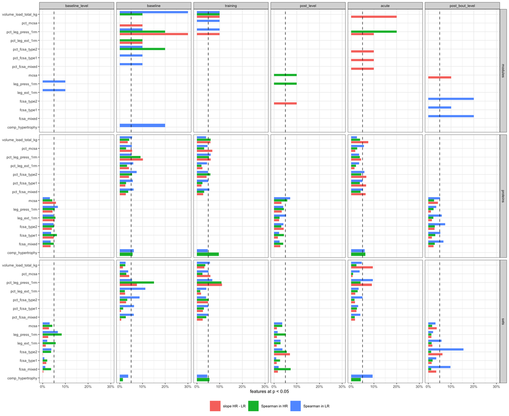

Figure 1: Share of features at p < 0.05 per test, window and trait. Dashed: 5%.

```r
counts |>
  mutate(
    test = if_else(test == "within_group", paste("Spearman in", group), "slope HR - LR"),
    window = factor(window, names(windows))
  ) |>
  ggplot(aes(share_nominal, trait, fill = test)) +
  geom_col(position = position_dodge(width = 0.8), width = 0.75) +
  geom_vline(xintercept = 0.05, linetype = "dashed", linewidth = 0.3) +
  facet_grid(feature_type ~ window, scales = "free_y", space = "free_y") +
  scale_x_continuous(labels = scales::label_percent()) +
  labs(x = "features at p < 0.05", y = NULL, fill = NULL) +
  theme_bw(base_size = 7) +
  theme(legend.position = "bottom")
```

## Validation

```r
stopifnot(
  all(within$fdr >= within$p, na.rm = TRUE), all(abs(within$rho) <= 1, na.rm = TRUE),
  all(between$fdr >= between$p), !"comp_hypertrophy" %in% between$trait,
  all(within$n_people >= 7), all(between$n_people >= 15), all(trait_effects$n >= 7),
  all(trait_effects$lower <= trait_effects$pct_change),
  all(trait_effects$pct_change <= trait_effects$upper),
  isTRUE(all.equal(
    filter(trait_effects, trait == "mcsa", group == "HR")$pct_change,
    with(filter(phenotype, group == "HR"), as_pct(mean(log(mcsa_post_cm2 / mcsa_pre_cm2))))
  ))
)
```

## Summary

```r
tally <- \(name) summarise(filter(counts, test == name), across(starts_with("n_"), sum))
between_n <- tally("group_difference")
within_n <- tally("within_group")
```

Slope difference (limma, feature ~ group × trait): 136,149 tests, 4,900 at p < 0.05 (chance: 6,807), 50 at FDR < 0.05. Within each group (Spearman): 292,126 tests, 12,927 at p < 0.05 (chance: 14,606), 15 at FDR < 0.05.

## Save

`group_trait_slopes.rds` holds both tables and the counts for the figures.

```r
out <- here("02_HRvLR", "07_Group_Trait_Slopes", "c_data")
dir.create(out, showWarnings = FALSE)
saveRDS(
  list(
    trait_effects = trait_effects, counts = counts, within_group = within,
    group_difference = between
  ),
  file.path(out, "group_trait_slopes.rds")
)
write_workbook(
  list(
    trait_effects = trait_effects,
    counts = counts,
    within_group = arrange(within, feature_type, window, trait, group, p),
    group_difference = arrange(between, feature_type, window, trait, p)
  ),
  c(
    "T1 to T2 % change per trait, geometric mean and 95% CI: per group (t-test), HR - LR (Welch).",
    "Tested, p < 0.05 and FDR < 0.05 per test, group, feature type, window and trait.",
    "Spearman rho and exact p within each group, per feature, window and trait.",
    "limma, feature ~ group * trait: HR slope minus LR slope with its 95% CI, t, p and FDR."
  ),
  file.path(out, "group_trait_slopes.xlsx"), inputs, paths
)
```